# Timing a speed test with a smartphone: a video tool to replace timing gates

Application example: the Illinois agility test in 20 young ice hockey players

Author

Sarah Durand

Published

November 10, 2026

# 1 Identification

- **University:** Université de Montpellier, UFR STAPS
- **Programme:** Master 1 Ingénierie et Ergonomie de l’Activité Physique (IEAP), SHAI track (Sport, Health and Artificial Intelligence)
- **Academic year:** 2026-2027
- **Course:** Python, R and Git for data analysis (SA1M118)
- **Teacher:** Denis Mottet
- **Student:** Sarah Durand
- **Project title:** Timing a speed test with a smartphone: a video tool to replace timing gates
- **Date:** December 2026
- **Data origin:** videos of the Illinois agility test (performed off-ice), recorded during the 2026 autumn holiday camp organised by Hock’Bean Training, a structure that supports and monitors young ice hockey players. I took part as a volunteer to set up and test the tool.
- **GitHub repository:** https://github.com/sdurand875-spec/projet-final-soutenance

# 2 Introduction

Speed and agility tests are a standard part of the monitoring of young athletes. To time them accurately, timing gates (photoelectric cells) are usually used. This equipment is expensive: about €1,500 to €3,000 for a kit of a few gates (Microgate Witty, Tendo Sprint System). It also takes time to set up and to learn how to use. For many sports structures, spending such an amount for a few tests per year is not realistic, especially since the monitoring of young players does not require a precision to the thousandth of a second.

The most common alternative, the hand-held stopwatch, is not satisfactory either: the coach’s reaction time at the start and at the finish introduces an error, whereas on a test lasting about fifteen seconds, a few tenths of a second can change the interpretation.

The My Jump app (Balsalobre-Fernández et al., 2015) showed that a smartphone filming in slow motion can accurately measure a performance by manually selecting key frames. We applied the same principle: the test is filmed in slow motion (240 frames per second), the user selects the start frame and the finish frame, and the program computes the time.

This project addresses two questions:

1. Can we build a simple, low-cost video tool to time any test that starts and finishes on the same line?
2. Applied to the Illinois agility test, can this tool highlight a relationship between time and age in young ice hockey players?

# 3 Data

**Participants.** Twenty young ice hockey players (17 boys, 3 girls), aged 8.8 to 17.7 years, performed the Illinois agility test during the 2026 autumn holiday camp.

**Test conditions.** The test was performed off-ice, on a concrete car park. It had rained the day before, so the ground was still damp and rather slippery. Before the test, players coming from an on-ice session did a brief warm-up; the others did a full warm-up (running drills, slaloms and sprints).

**Protocol.** Players started standing, 1 m behind the start/finish line. Each player performed one trial; players aged U13 and under could perform a second trial if they wished, and the best of the two was kept. On the video, the start frame and the finish frame are the frames where the player’s hips are level with the cone marking the start/finish line. The test time is therefore the time between the two crossings of this line by the hips.

**Video acquisition.** Videos were recorded with an iPhone 13 in slow-motion mode (240 frames per second), fixed on a tripod 2–3 m from the start cone, facing the start/finish line. A single camera is enough, since the start and the finish are on the same line.

**Privacy.** As the participants are minors, videos, names and birth dates are not shared. Each player is given an anonymous id (P01 to P20). Only the age at the time of the test and the sex are published, in the file `results/measures_anonymous.csv`.

# 4 Methods: Python (video timing tool)

## 4.1 General workflow

For each video, the user gives the real recording frequency; a window then shows the video frame by frame. The user moves with the arrow keys or a progress bar, presses Enter on the start frame, then on the finish frame. The time is computed as:

$$\text{time} = \frac{\text{finish frame} - \text{start frame}}{\text{recording frequency}}$$

The result is saved in a CSV file after each video.

## 4.2 The recording frequency trap

In slow-motion mode, the iPhone records at 240 frames per second but stores the video so that it is played at 30 frames per second: this is what creates the slow-motion effect. The video file therefore states 30 frames/s, a wrong value for our computation.

Example with one of our videos, which contains 5,522 frames:

- with the frequency stored in the file: 5,522 / 30 = 184 s, i.e. more than 3 minutes, which is impossible;
- with the real frequency: 5,522 / 240 = 23 s, which matches the real duration of the video.

The error is a factor of 8 (240 / 30). The same applies to the test time: a player whose start frame is 646 and finish frame is 5,217 has a time of 4,571 / 240 = 19.05 s. With the frequency of the file, we would have obtained 4,571 / 30 = 152.4 s.

The program therefore does not rely on the frequency stored in the file: it displays it for information, then **asks the user for the real frequency** (240 by default).

The frequency also sets the precision of the measurement. At 240 frames/s, one frame lasts 1/240 = 4.2 ms; at 30 frames/s, it would last 33 ms. Slow motion makes the measurement 8 times more precise.

## 4.3 Anonymisation and data protection

The participants are minors. Their name, birth date and image are personal data that must not appear in a public GitHub repository: the image-rights authorisation signed for the camp covers use by the structure, not public distribution on the Internet. The videos are also too large (about 200 MB each) for GitHub, which is limited to 100 MB per file.

This was solved as follows:

- each player receives an **anonymous id** (P01 to P20), assigned automatically by the program;
- the **birth date** is only used to compute the **age at the time of the test**; only this age is published;
- the files containing personal information (videos, measures with names, name → id correspondence table, birth dates) **stay only on my computer**; the `.gitignore` file prevents them from being sent to GitHub;
- the only published results file, `results/measures_anonymous.csv`, contains only the id, the frame numbers, the frequency, the time, the age and the sex.

Thanks to the `MEASURE = False` switch in `main.ipynb`, the project runs without the videos: it directly reads this anonymous file.

## 4.4 Code organisation

The Python code is split into two files:

- `main.ipynb` is the **entry point**: it only contains the settings (folders, `MEASURE` switch) and the function calls;
- `sources/video_timing.py` contains **all the functions**, grouped by theme: video information, display, measurement, results files, anonymisation.

The notebook thus stays short and readable, and each function can be modified without affecting the rest.

Table 1: Functions of `sources/video_timing.py`

| Theme | Function | Input | Output | Role |
| --- | --- | --- | --- | --- |
| **Video information** | `get_video_info` | video path | file frequency, number of frames | read the video information |
|  | `ask_fps` | file frequency, default frequency (240) | real frequency | ask the user for the real frequency, rejecting invalid values |
|  | `get_name_from_file` | video path | player name | read the player’s name from the file name (spaces become `_`) |
| **Display** | `put_text` | image, text, position, colour, size | (modified image) | write a text with a black outline, readable on any background |
|  | `frame_to_x` | frame number, number of frames, width | horizontal position | convert a frame number into a position on the progress bar |
|  | `draw_display` | frame, position, number of frames, frequency, start, finish | image to display | assemble the frame, the texts (time, START/END) and the progress bar |
| **Measurement** | `measure_test` | video path, real frequency, display scale | name, start and finish frames, frequency, time (or nothing if cancelled) | open the measurement window, handle the keyboard, compute the time |
|  | `on_mouse` (inside `measure_test`) | mouse event, position | (updated position) | jump in the video by clicking or dragging on the bar |
| **Results files** | `list_videos` | folder | sorted list of videos | find the video files in the folder (.mov, .mp4, .m4v, .avi) |
|  | `load_results` | CSV file | results table | read the results, or return an empty table if the file does not exist |
|  | `save_result` | result, CSV file | (updated file) | save a result, replacing the old one if the video was already measured |
|  | `measure_all_videos` | folder, CSV file, frequency, `redo` option | (updated file) | measure all videos one after the other, skipping those already done |
| **Anonymisation** | `make_id_table` | list of names, correspondence file | name → id table | assign the ids P01, P02…, never changing those already given |
|  | `anonymize_results` | measures, id table, dates, output file | anonymous file | create the published file: id, frames, frequency, time, age, sex |

## 4.5 A privacy error corrected with Git

During the first upload to GitHub, the file `data/children_info.csv`, which contains the names and birth dates, was published by mistake: the line that should have excluded it had been forgotten in the `.gitignore`. The repository was still private, so the file was never publicly visible. The error was spotted by checking the list of uploaded files.

Simply deleting the file would not have been enough: it would have remained visible in the Git history. The correction was done in four steps:

1. add `data/children_info.csv` to the `.gitignore`;
2. `git rm --cached data/children_info.csv`: remove the file from Git without deleting it from the computer;
3. `git commit --amend`: replace the first commit with a version without this file;
4. `git push --force`: replace the version stored on GitHub.

As GitHub can keep an old commit accessible through a direct link, the repository was deleted and published again before being made public. Lesson learned: always check the list of uploaded files before the first commit.

# 5 Methods: R (statistical analysis)

**Link between Python and R.** The statistical analysis is done in `main.qmd`, a Quarto document run in RStudio. It reads the only file produced by Python, `results/measures_anonymous.csv`, with a path built by `file.path()` so that it works on Windows, Mac and Linux. R therefore never has access to the names or the videos. Graphics are made with the `ggplot2` package.

**Description of performances.** Players are ranked from the fastest to the slowest. Times are summarised with the **median** and the **quartiles** (Q1 and Q3) rather than the mean and standard deviation: with 20 players, the median is less sensitive to extreme values.

**Relationship between time and age.**

- A **scatter plot** (time against age) shows the relationship, with the regression line and its 95% confidence interval.
- The **Pearson correlation** (r) measures the strength and direction of the relationship.
- A **linear regression** (time = a + b × age) estimates the slope b, i.e. the number of seconds gained per year of age, and the R², i.e. the proportion of the differences in time explained by age.

**Model checking.** Linear regression assumes that the residuals are normally distributed and that their spread is constant. This is checked with a **QQ plot** and the **Shapiro-Wilk test** for normality, and with a plot of the **residuals against the fitted values** for the spread. With only 20 players, these checks remain limited: the Shapiro-Wilk test has little power to detect a departure from normality, and the plots are harder to interpret with few points. Conclusions must therefore remain cautious.

The significance level is set at **α = 0.05**. Sex is not analysed statistically, as the sample includes only 3 girls.

# 6 Results

## 6.1 Ranking of the players

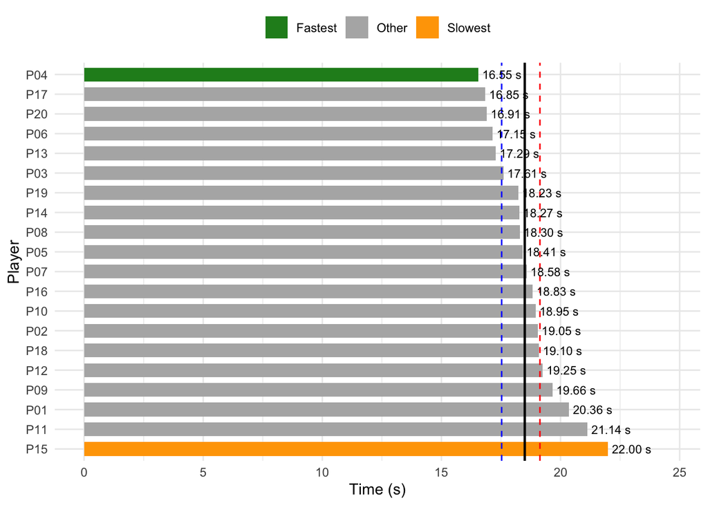

Figure 1: Illinois time of each player, from the fastest (top) to the slowest (bottom). Black line: median; blue dashed: Q1; red dashed: Q3.

Illinois times range from 16.55 s for the fastest player (P04) to 22.00 s for the slowest (P15), a difference of 5.4 s (Figure 1). The median is 18.50 s. Half of the players are between 17.53 s (Q1) and 19.14 s (Q3), an interquartile range of 1.6 s.

## 6.2 Time and age

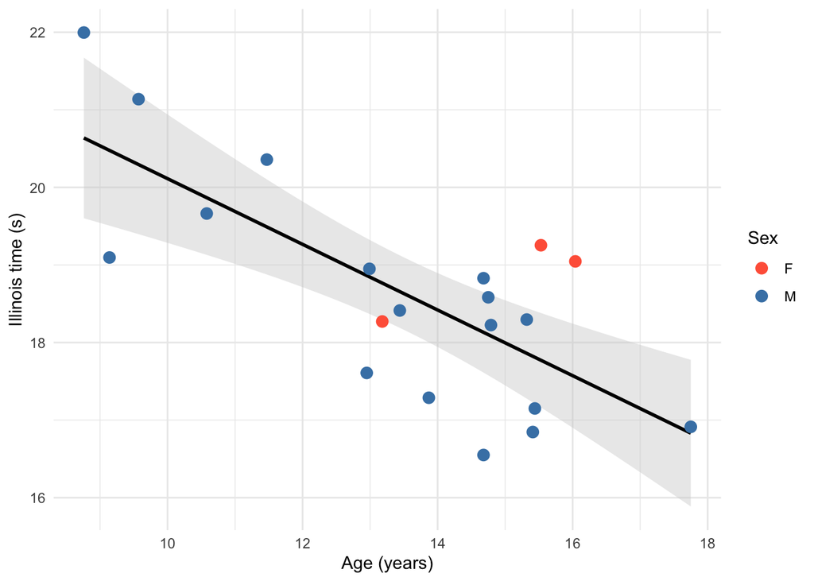

Figure 2: Illinois time according to age. Line: linear regression and its 95% confidence interval.

Table 2: Linear regression of the Illinois time on age.

|  | Estimate | Std. error | t | p |
| --- | --- | --- | --- | --- |
| (Intercept) | 24.3453 | 1.2690 | 19.1850 | 0e+00 |
| age_years | -0.4233 | 0.0924 | -4.5797 | 2e-04 |

The Illinois time decreases with age (Figure 2). The correlation is strong and negative: r = −0.73 (95% CI: −0.89 to −0.43), p < 0.001. The linear regression (Table 2) estimates a slope of −0.42 s per year of age (95% CI: −0.62 to −0.23): over the age range of the sample (8.8 to 17.7 years), this represents a difference of about 3.8 s. Age explains 54% of the differences in time between players (R² = 0.54). The intercept is not interpreted, as it corresponds to an age of 0 years.

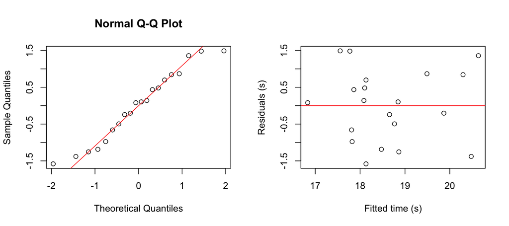

Figure 3: Left: QQ plot of the residuals. Right: residuals against fitted values.

The residuals follow the line of the QQ plot (Figure 3, left; Shapiro-Wilk test: W = 0.95, p = 0.44) and are randomly spread around 0 with a roughly constant spread (Figure 3, right). The conditions of the linear regression are therefore met, with the caution required by the small sample size.

# 7 Discussion

**A simple, low-cost tool.** The first aim is achieved: the tool can time any test that starts and finishes on the same line, with a smartphone and a tripod, instead of a timing-gate kit costing €1,500–3,000. Filmed at 240 frames/s, it offers a theoretical precision of 4.2 ms (one frame), which is largely sufficient for monitoring young players. It is quick to set up (a single camera), and measuring one video takes 1 to 2 minutes. The main technical trap, the recording frequency stated in the file (30 instead of 240 frames/s), was identified and corrected.

**Time decreases with age.** Applied to the Illinois agility test, the tool highlights a strong relationship between age and performance: players gain on average 0.42 s per year, and age explains about half of the differences between players. This result is in line with expectations: with growth, speed develops, but so do lower-limb strength and power, which are essential in the Illinois test to accelerate, brake and absorb changes of direction. In young ice hockey players, change-of-direction performance is related to lower-limb power and skeletal robustness, and these qualities change rapidly during growth and maturation (Slavicek et al., 2022). The other half of the variability remains unexplained: training level, maturation, morphology, etc.

**Limitations.**

- **The tool was not compared with timing gates**: its real accuracy (bias, error) is therefore unknown.
- **Frame selection is manual**: despite a precise criterion (hips level with the cone), some subjectivity remains. Reproducibility (same observer twice, or two observers) was not tested. The camera angle can also make it harder to identify exactly when the hips cross the line.
- **The sample is small** (20 players, including 3 girls), with a single trial (two for some U13 players): statistical conclusions remain cautious.
- **Conditions were not standardised**: damp and slippery ground, different warm-ups depending on whether players came from an on-ice session or not.
- **The test was performed off-ice**: the use of the tool on ice remains to be checked. For ice hockey players, the off-ice Illinois test is nevertheless a relevant indicator, as it is moderately related to on-ice performance (Slavicek et al., 2022).
- **Physical characteristics** (height, body mass, maturation) were not measured.

**Possible improvements.**

- compare the tool with timing gates on the same trials, and test its reproducibility;
- automatically detect when the line is crossed, to remove the manual part and save time;
- test the tool on ice;
- include more players, especially girls, and measure height, body mass and maturation;
- standardise the warm-up and ground conditions.

**Conclusion.** This project shows that a smartphone and a simple program can replace timing gates for monitoring speed and agility tests, provided that the tool is validated against a reference measurement.

# 8 Use of AI

The idea of the project, the choice of the test, the protocol, the filming and the measurement of the 20 videos were carried out by the author. The way the tool works (frame-by-frame navigation, progress bar, START/END marking, criterion of the hips level with the cone) and the analysis choices (median and quartiles, relationship with age) were defined by the author.

Most of the Python and R code was written with Claude (Anthropic), based on these instructions. Each step was tested on the videos, and the problems encountered were identified and corrected along the way (30/240 frames/s frequency, file errors, anonymisation).

For the writing, Claude proposed an outline and a first draft in French based on the information provided by the author. This text was reviewed, corrected and completed by the author (context, protocol, interpretation, bibliographic reference), then translated into English by Claude.

# 9 References

## 9.1 Articles

- Balsalobre-Fernández, C., Glaister, M., & Lockey, R. A. (2015). The validity and reliability of an iPhone app for measuring vertical jump performance. *Journal of Sports Sciences*, 33(15), 1574–1579.
- Slavicek, T., Stastny, P., Roczniok, R., & Musalek, M. (2022). Lower limb skeletal robustness determines the change of directional speed performance in youth ice hockey. *Journal of Human Kinetics*, 85, 75–85. https://doi.org/10.2478/hukin-2022-0111

## 9.2 Timing gates (prices consulted in November 2026)

- Microgate Witty kit: https://mediceval.fr/home/1691-kit-panneau-witty-pro-3-cellules-microgate.html
- Tendo Sprint System: https://www.cress-sport.com/technologie/chronometrage/tendo-sport-sprint-system

## 9.3 Software and libraries

- Python: https://www.python.org, with OpenCV (https://opencv.org), NumPy (https://numpy.org) and pandas (https://pandas.pydata.org).
- R Core Team. *R: A language and environment for statistical computing*. R Foundation for Statistical Computing, Vienna, Austria. https://www.R-project.org
- Wickham, H. (2016). *ggplot2: Elegant Graphics for Data Analysis*. Springer-Verlag New York.
- Quarto: https://quarto.org
- Claude (Anthropic): https://www.anthropic.com/claude